# Forecasting_Cocoa_Bean_Imports_FIXED

## Model 3: Prophet

I also fit the Prophet model to see if it improves performance:

```python
df=monthly_df.copy()
df['ds'] = df['Import Date']
df['y'] = df['Weight']
```

```python
df.drop(df.columns[0:6], axis=1, inplace=True)
```

```python
df.head()
```

|  | ds | y |
| --- | --- | --- |
| 0 | 2020-01-01 | 77863938 |
| 1 | 2020-02-01 | 118967413 |
| 2 | 2020-03-01 | 117594405 |
| 3 | 2020-04-01 | 72523979 |
| 4 | 2020-05-01 | 58180114 |

Fit data with yearly seasonality (seasonality by month) as as initial baseline:

```python
m = Prophet(yearly_seasonality=True, weekly_seasonality=False, daily_seasonality=False)
m.fit(df)
```

Add future 3 months for forecast:

```python
future = m.make_future_dataframe(periods=3, freq='MS')
print(future.head())
print(future.tail())
```

```
          ds
0 2020-01-01
1 2020-02-01
2 2020-03-01
3 2020-04-01
4 2020-05-01
           ds
58 2024-11-01
59 2024-12-01
60 2025-01-01
61 2025-02-01
62 2025-03-01
```

Forecast the next 3 months (with a CI):

```python
forecast = m.predict(future)
print(forecast.columns)
forecast[['ds', 'yhat', 'yhat_lower', 'yhat_upper']].tail()
```

```
Index(['ds', 'trend', 'yhat_lower', 'yhat_upper', 'trend_lower', 'trend_upper',
       'additive_terms', 'additive_terms_lower', 'additive_terms_upper',
       'yearly', 'yearly_lower', 'yearly_upper', 'multiplicative_terms',
       'multiplicative_terms_lower', 'multiplicative_terms_upper', 'yhat'],
      dtype='object')
```

|  | ds | yhat | yhat_lower | yhat_upper |
| --- | --- | --- | --- | --- |
| 58 | 2024-11-01 | 2.387980e+06 | -1.588334e+07 | 2.176104e+07 |
| 59 | 2024-12-01 | 1.790853e+07 | -1.263356e+06 | 3.646359e+07 |
| 60 | 2025-01-01 | 6.511386e+07 | 4.651289e+07 | 8.381275e+07 |
| 61 | 2025-02-01 | 3.929141e+07 | 1.980159e+07 | 5.699398e+07 |
| 62 | 2025-03-01 | 7.277707e+07 | 5.357060e+07 | 9.143605e+07 |

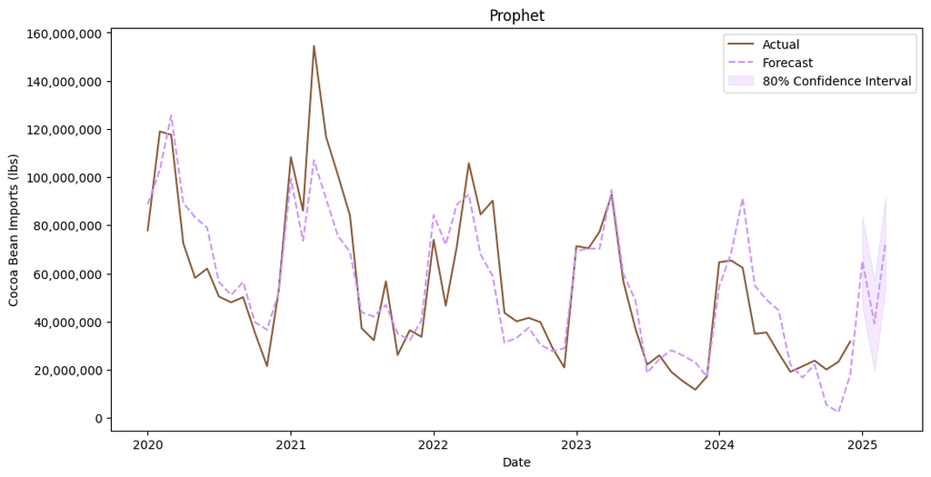

```python
plt.figure(figsize=(12, 6))

plt.plot(df["ds"], df["y"], label="Actual", color=custom_palette[2])

plt.plot(forecast["ds"], forecast["yhat"], label="Forecast", color=custom_palette[0], linestyle='--')

future_forecast = forecast[forecast['ds'] > df['ds'].max()]
plt.fill_between(
    future_forecast['ds'],
    future_forecast['yhat_lower'],
    future_forecast['yhat_upper'],
    color=custom_palette[0], alpha=0.2, label='80% Confidence Interval'
)

ax = plt.gca()
ax.yaxis.set_major_formatter(mtick.StrMethodFormatter('{x:,.0f}'))

plt.legend()
plt.ylabel("Cocoa Bean Imports (lbs)")
plt.xlabel("Date")
plt.title("Prophet")
plt.show()
```

Prophet's Decomposition:

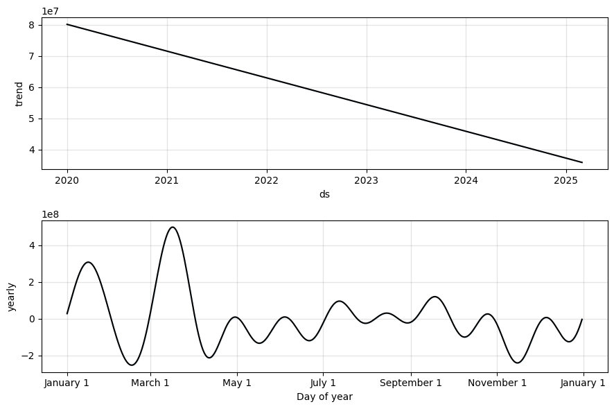

```python
fig = m.plot_components(forecast)

for ax in fig.axes:
    for line in ax.get_lines():
        line.set_color('black')
plt.show()
```

Cross validation for predicting rolling 1-3 months out from training data:

```python
period = "1MS"  # Month start
cutoffs = pd.date_range(start="2023-09-01", end="2024-07-01", freq=period) # End is last starting date
horizon = "93 days"  # Forecast horizon for each cutoff
prophet_cv = cross_validation(m, cutoffs=cutoffs, horizon=horizon, disable_tqdm=True)

prophet_cv['AE'] = abs(prophet_cv['yhat'] - prophet_cv['y'])
prophet_cv['APE'] = abs(prophet_cv['yhat'] - prophet_cv['y']) / abs(prophet_cv['y'])

prophet_cv['ds'] = pd.to_datetime(prophet_cv['ds'])
prophet_cv['cutoff'] = pd.to_datetime(prophet_cv['cutoff'])
prophet_cv['horizon'] = prophet_cv['ds'].dt.to_period('M').astype(int) - prophet_cv['cutoff'].dt.to_period('M').astype(int)

prophet_cv.style.format({'ds':'{:%m-%d-%Y}','cutoff':'{:%m-%d-%Y}','y':'{:,.0f}','yhat':'{:,.0f}','yhat_lower':'{:,.0f}','yhat_upper':'{:,.0f}','AE': '{:,.0f}', 'APE': '{:.2f}'})
```

[output not shown]

|  | ds | yhat | yhat_lower | yhat_upper | y | cutoff | AE | APE | horizon |
| --- | --- | --- | --- | --- | --- | --- | --- | --- | --- |
| 0 | 10-01-2023 | 34,571,294 | 16,929,854 | 52,300,645 | 15,172,388 | 09-01-2023 | 19,398,906 | 1.28 | 1 |
| 1 | 11-01-2023 | 36,122,420 | 18,245,770 | 52,255,631 | 11,741,002 | 09-01-2023 | 24,381,418 | 2.08 | 2 |
| 2 | 12-01-2023 | 6,271,949 | -9,598,850 | 23,445,941 | 17,305,596 | 09-01-2023 | 11,033,647 | 0.64 | 3 |
| 3 | 11-01-2023 | 39,374,964 | 23,385,461 | 56,874,108 | 11,741,002 | 10-01-2023 | 27,633,962 | 2.35 | 1 |
| 4 | 12-01-2023 | 8,371,796 | -8,831,315 | 25,519,546 | 17,305,596 | 10-01-2023 | 8,933,800 | 0.52 | 2 |
| 5 | 01-01-2024 | 50,233,151 | 33,238,142 | 67,156,617 | 64,702,033 | 10-01-2023 | 14,468,882 | 0.22 | 3 |
| 6 | 12-01-2023 | 14,152,574 | -3,117,462 | 31,062,282 | 17,305,596 | 11-01-2023 | 3,153,022 | 0.18 | 1 |
| 7 | 01-01-2024 | 49,940,755 | 32,061,018 | 68,962,455 | 64,702,033 | 11-01-2023 | 14,761,278 | 0.23 | 2 |
| 8 | 02-01-2024 | 78,604,042 | 60,051,070 | 95,263,367 | 65,375,575 | 11-01-2023 | 13,228,467 | 0.20 | 3 |
| 9 | 01-01-2024 | 49,872,672 | 32,245,314 | 67,248,874 | 64,702,033 | 12-01-2023 | 14,829,361 | 0.23 | 1 |
| 10 | 02-01-2024 | 78,598,462 | 61,289,389 | 97,393,705 | 65,375,575 | 12-01-2023 | 13,222,887 | 0.20 | 2 |
| 11 | 03-01-2024 | 106,659,231 | 89,317,085 | 123,659,483 | 62,364,919 | 12-01-2023 | 44,294,312 | 0.71 | 3 |
| 12 | 02-01-2024 | 79,579,136 | 62,051,163 | 96,549,506 | 65,375,575 | 01-01-2024 | 14,203,561 | 0.22 | 1 |
| 13 | 03-01-2024 | 108,929,837 | 91,319,256 | 126,149,664 | 62,364,919 | 01-01-2024 | 46,564,918 | 0.75 | 2 |
| 14 | 04-01-2024 | 64,384,252 | 48,206,371 | 81,351,503 | 34,933,233 | 01-01-2024 | 29,451,019 | 0.84 | 3 |
| 15 | 03-01-2024 | 106,524,646 | 88,859,720 | 123,044,772 | 62,364,919 | 02-01-2024 | 44,159,727 | 0.71 | 1 |
| 16 | 04-01-2024 | 62,391,175 | 44,772,206 | 79,368,691 | 34,933,233 | 02-01-2024 | 27,457,942 | 0.79 | 2 |
| 17 | 05-01-2024 | 52,155,620 | 34,999,897 | 69,397,706 | 35,504,037 | 02-01-2024 | 16,651,583 | 0.47 | 3 |
| 18 | 04-01-2024 | 62,532,257 | 44,824,399 | 82,380,783 | 34,933,233 | 03-01-2024 | 27,599,024 | 0.79 | 1 |
| 19 | 05-01-2024 | 51,432,949 | 32,080,191 | 68,912,081 | 35,504,037 | 03-01-2024 | 15,928,912 | 0.45 | 2 |
| 20 | 06-01-2024 | 51,258,120 | 32,798,947 | 70,240,545 | 26,935,635 | 03-01-2024 | 24,322,485 | 0.90 | 3 |
| 21 | 05-01-2024 | 51,418,592 | 33,825,254 | 69,345,604 | 35,504,037 | 04-01-2024 | 15,914,555 | 0.45 | 1 |
| 22 | 06-01-2024 | 50,860,837 | 31,374,903 | 69,865,398 | 26,935,635 | 04-01-2024 | 23,925,202 | 0.89 | 2 |
| 23 | 07-01-2024 | 20,165,735 | 1,083,522 | 38,248,827 | 19,175,494 | 04-01-2024 | 990,241 | 0.05 | 3 |
| 24 | 06-01-2024 | 50,956,609 | 32,704,522 | 70,184,129 | 26,935,635 | 05-01-2024 | 24,020,974 | 0.89 | 1 |
| 25 | 07-01-2024 | 20,052,688 | 1,345,047 | 38,428,082 | 19,175,494 | 05-01-2024 | 877,194 | 0.05 | 2 |
| 26 | 08-01-2024 | 11,858,470 | -5,635,972 | 31,271,205 | 21,449,146 | 05-01-2024 | 9,590,676 | 0.45 | 3 |
| 27 | 07-01-2024 | 20,360,144 | 3,062,241 | 39,273,490 | 19,175,494 | 06-01-2024 | 1,184,650 | 0.06 | 1 |
| 28 | 08-01-2024 | 11,755,945 | -5,622,807 | 30,095,651 | 21,449,146 | 06-01-2024 | 9,693,201 | 0.45 | 2 |
| 29 | 09-01-2024 | 21,479,723 | 3,124,096 | 39,337,768 | 23,828,291 | 06-01-2024 | 2,348,568 | 0.10 | 3 |
| 30 | 08-01-2024 | 11,759,345 | -5,355,922 | 31,470,017 | 21,449,146 | 07-01-2024 | 9,689,801 | 0.45 | 1 |
| 31 | 09-01-2024 | 21,470,890 | 3,739,985 | 39,615,374 | 23,828,291 | 07-01-2024 | 2,357,401 | 0.10 | 2 |
| 32 | 10-01-2024 | -2,962,042 | -20,434,241 | 15,681,012 | 20,121,692 | 07-01-2024 | 23,083,734 | 1.15 | 3 |

```python
MAE_by_horizon = prophet_cv.groupby(['horizon'])['AE'].mean()
MAE_by_horizon = pd.DataFrame(MAE_by_horizon).rename(columns={'AE': 'MAE'})

MAPE_by_horizon = prophet_cv.groupby(['horizon'])['APE'].mean()
MAPE_by_horizon = pd.DataFrame(MAPE_by_horizon).rename(columns={'APE': 'MAPE'})

prophet_horizon_table = MAE_by_horizon.merge(MAPE_by_horizon, on='horizon')
prophet_horizon_table.style.format({'MAE': '{:,.0f}', 'MAPE': '{:.0%}'})
```

| horizon | MAE | MAPE |
| --- | --- | --- |
| 1 | 18,344,322 | 69% |
| 2 | 17,100,378 | 59% |
| 3 | 17,223,965 | 52% |

```python
prophet_p = performance_metrics(prophet_cv, rolling_window=1)
prophet_p.style.format({
    'mse': '{:,.0f}',
    'rmse': '{:,.0f}',
    'mae': '{:,.0f}',
    'mape': '{:.0%}',
    'coverage': '{:.0%}',
    'mdape': '{:.0%}',
    'smape': '{:.0%}',
    'coverage' : '{:.0%}'
})
```

|  | horizon | mse | rmse | mae | mape | mdape | smape | coverage |
| --- | --- | --- | --- | --- | --- | --- | --- | --- |
| 0 | 92 days 00:00:00 | 453,339,460,451,128 | 21,291,770 | 17,556,222 | 60% | 45% | 50% | 61% |

```python
prophet_overall_MAE  = prophet_cv['AE'].mean()
prophet_overall_MAPE = prophet_cv['APE'].mean()

print(f"MAE:{prophet_overall_MAE:,.0f}")
print(f"MAPE (%): {prophet_overall_MAPE:.0%}")
```

```
MAE:17,556,222
MAPE (%): 60%
```

Tuning the model:

Grid Search with hyperparameter options:

```python
param_grid = {
    'changepoint_prior_scale': [0.001, 0.01, 0.02],
    'changepoint_range': [0.8, 0.95],
    'seasonality_prior_scale': [0.1, 1.0, 5.0],
    'seasonality_mode': ['additive', 'multiplicative'],
    'growth': ['linear', 'logistic']
}

all_params = list(itertools.product(*param_grid.values()))
rmses = []

for params in all_params:
    param_dict = dict(zip(param_grid.keys(), params))
    temp_df = df.copy()

    if param_dict['growth'] == 'logistic':
        temp_df['floor'] = 0
        temp_df['cap'] = temp_df['y'].max() * 1.2

    model = Prophet(
        yearly_seasonality=True,
        weekly_seasonality=False,
        daily_seasonality=False,
        **param_dict
    )
    model.fit(temp_df)

    df_cv = cross_validation(model, cutoffs=cutoffs, horizon='93 days', disable_tqdm=True)
    df_p = performance_metrics(df_cv, rolling_window=1)
    rmses.append(df_p['rmse'].mean())

tuning_results = pd.DataFrame([dict(zip(param_grid.keys(), p)) for p in all_params])
tuning_results['rmse'] = rmses
print(tuning_results.nsmallest(1, 'rmse'))
```

Best parameters:

```python
best_params_prep = all_params[np.argmin(rmses)]
best_params = dict(zip(param_grid.keys(), best_params_prep))

print(best_params)
```

```
{'changepoint_prior_scale': 0.01, 'changepoint_range': 0.8, 'seasonality_prior_scale': 0.1, 'seasonality_mode': 'multiplicative', 'growth': 'linear'}
```

Plot model fit and forecast, including floor and cap since seasonality mode chose 'multiplicative' - because it needs guardrails:

```
16:48:17 - cmdstanpy - INFO - Chain [1] start processing
16:48:17 - cmdstanpy - INFO - Chain [1] done processing
```

```
           ds          yhat    yhat_lower    yhat_upper
0  2020-01-01  9.962309e+07  7.728316e+07  1.192664e+08
1  2020-02-01  9.822106e+07  7.851117e+07  1.183878e+08
2  2020-03-01  1.212633e+08  1.003751e+08  1.409421e+08
3  2020-04-01  1.050092e+08  8.537475e+07  1.263587e+08
4  2020-05-01  8.638201e+07  6.760903e+07  1.061323e+08
..        ...           ...           ...           ...
58 2024-11-01  1.970418e+07  4.289487e+05  4.089143e+07
59 2024-12-01  2.307426e+07  4.615000e+06  4.479443e+07
60 2025-01-01  4.070195e+07  1.941385e+07  5.989525e+07
61 2025-02-01  3.952993e+07  1.908779e+07  5.936743e+07
62 2025-03-01  4.800308e+07  2.820561e+07  6.871246e+07

[63 rows x 4 columns]
```

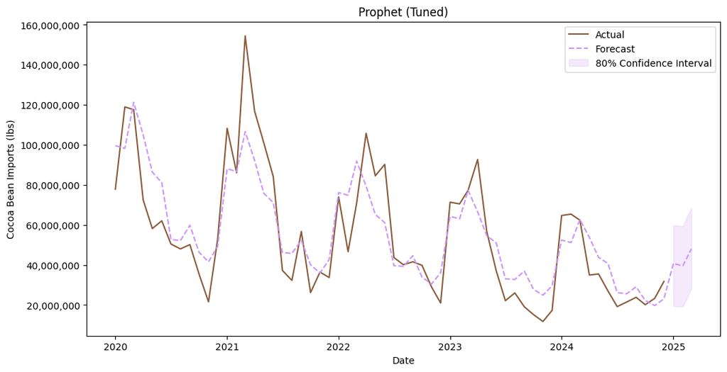

```python
cap_value = df['y'].max() * 1.2

df = df.copy()
df['floor'] = 0
df['cap'] = cap_value

m = Prophet(
    yearly_seasonality=True,
    weekly_seasonality=False,
    daily_seasonality=False,
    **best_params
)

m.fit(df)

future = m.make_future_dataframe(periods=3, freq='MS')
future['floor'] = 0
future['cap'] = cap_value

forecast = m.predict(future)

print(forecast[['ds', 'yhat', 'yhat_lower', 'yhat_upper']])

plt.figure(figsize=(12, 6))

plt.plot(df["ds"], df["y"], label="Actual", color=custom_palette[2])

plt.plot(forecast["ds"], forecast["yhat"], label="Forecast", color=custom_palette[0], linestyle='--')

future_forecast = forecast[forecast['ds'] > df['ds'].max()]
plt.fill_between(
    future_forecast['ds'],
    future_forecast['yhat_lower'],
    future_forecast['yhat_upper'],
    color=custom_palette[0], alpha=0.2, label='80% Confidence Interval'
)

ax = plt.gca()
ax.yaxis.set_major_formatter(mtick.StrMethodFormatter('{x:,.0f}'))

plt.legend()
plt.ylabel("Cocoa Bean Imports (lbs)")
plt.xlabel("Date")
plt.title("Prophet (Tuned)")
plt.show()
```

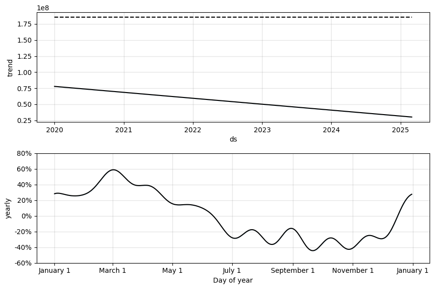

```python
fig = m.plot_components(forecast)

for ax in fig.axes:
    for line in ax.get_lines():
        line.set_color('black')
plt.show()
```

Cross validation for predicting rolling 1-3 months out from training data:

```python
period = "1MS"  # Month start
cutoffs = pd.date_range(start="2023-09-01", end="2024-08-01", freq=period) # End is last starting date
horizon = "92 days"  # Forecast horizon for each cutoff
prophet_tuned_cv = cross_validation(m, cutoffs=cutoffs, horizon=horizon, disable_tqdm=True)

prophet_tuned_cv['AE'] = abs(prophet_tuned_cv['yhat'] - prophet_tuned_cv['y'])
prophet_tuned_cv['APE'] = (abs(prophet_tuned_cv['yhat'] - prophet_tuned_cv['y']) / abs(prophet_tuned_cv['y']))

prophet_tuned_cv['ds'] = pd.to_datetime(prophet_tuned_cv['ds'])
prophet_tuned_cv['cutoff'] = pd.to_datetime(prophet_tuned_cv['cutoff'])
prophet_tuned_cv['horizon'] = prophet_tuned_cv['ds'].dt.to_period('M').astype(int) - prophet_tuned_cv['cutoff'].dt.to_period('M').astype(int)
prophet_tuned_cv.style.format({'ds':'{:%m-%d-%Y}','cutoff':'{:%m-%d-%Y}','y':'{:,.0f}','yhat':'{:,.0f}','yhat_lower':'{:,.0f}','yhat_upper':'{:,.0f}','AE': '{:,.0f}', 'APE': '{:.0%}'})
```

[output not shown]

|  | ds | yhat | yhat_lower | yhat_upper | y | cutoff | AE | APE | horizon |
| --- | --- | --- | --- | --- | --- | --- | --- | --- | --- |
| 0 | 10-01-2023 | 33,229,787 | 11,664,038 | 55,107,299 | 15,172,388 | 09-01-2023 | 18,057,399 | 119% | 1 |
| 1 | 11-01-2023 | 29,595,579 | 7,474,233 | 52,542,841 | 11,741,002 | 09-01-2023 | 17,854,577 | 152% | 2 |
| 2 | 12-01-2023 | 33,518,306 | 11,316,066 | 56,809,617 | 17,305,596 | 09-01-2023 | 16,212,710 | 94% | 3 |
| 3 | 11-01-2023 | 29,070,280 | 7,444,246 | 51,398,724 | 11,741,002 | 10-01-2023 | 17,329,278 | 148% | 1 |
| 4 | 12-01-2023 | 32,972,679 | 11,906,542 | 55,297,136 | 17,305,596 | 10-01-2023 | 15,667,083 | 91% | 2 |
| 5 | 01-01-2024 | 55,687,186 | 33,451,409 | 79,134,164 | 64,702,033 | 10-01-2023 | 9,014,847 | 14% | 3 |
| 6 | 12-01-2023 | 32,629,136 | 10,178,688 | 54,321,667 | 17,305,596 | 11-01-2023 | 15,323,540 | 89% | 1 |
| 7 | 01-01-2024 | 54,859,769 | 32,539,603 | 77,908,837 | 64,702,033 | 11-01-2023 | 9,842,264 | 15% | 2 |
| 8 | 02-01-2024 | 53,190,108 | 30,502,895 | 74,613,935 | 65,375,575 | 11-01-2023 | 12,185,467 | 19% | 3 |
| 9 | 01-01-2024 | 53,960,554 | 31,453,828 | 76,575,435 | 64,702,033 | 12-01-2023 | 10,741,479 | 17% | 1 |
| 10 | 02-01-2024 | 52,331,759 | 27,977,161 | 72,979,562 | 65,375,575 | 12-01-2023 | 13,043,816 | 20% | 2 |
| 11 | 03-01-2024 | 65,484,230 | 44,422,431 | 87,358,738 | 62,364,919 | 12-01-2023 | 3,119,311 | 5% | 3 |
| 12 | 02-01-2024 | 53,740,013 | 31,782,154 | 75,018,236 | 65,375,575 | 01-01-2024 | 11,635,562 | 18% | 1 |
| 13 | 03-01-2024 | 67,386,820 | 44,595,487 | 89,681,636 | 62,364,919 | 01-01-2024 | 5,021,901 | 8% | 2 |
| 14 | 04-01-2024 | 59,994,313 | 39,978,217 | 81,240,379 | 34,933,233 | 01-01-2024 | 25,061,080 | 72% | 3 |
| 15 | 03-01-2024 | 69,350,348 | 49,191,804 | 89,845,352 | 62,364,919 | 02-01-2024 | 6,985,429 | 11% | 1 |
| 16 | 04-01-2024 | 61,888,080 | 40,804,267 | 85,041,513 | 34,933,233 | 02-01-2024 | 26,954,847 | 77% | 2 |
| 17 | 05-01-2024 | 49,866,421 | 28,641,993 | 71,141,075 | 35,504,037 | 02-01-2024 | 14,362,384 | 40% | 3 |
| 18 | 04-01-2024 | 60,571,527 | 38,448,887 | 82,950,568 | 34,933,233 | 03-01-2024 | 25,638,294 | 73% | 1 |
| 19 | 05-01-2024 | 48,773,749 | 26,712,346 | 69,985,555 | 35,504,037 | 03-01-2024 | 13,269,712 | 37% | 2 |
| 20 | 06-01-2024 | 45,989,469 | 24,985,167 | 66,965,842 | 26,935,635 | 03-01-2024 | 19,053,834 | 71% | 3 |
| 21 | 05-01-2024 | 46,132,527 | 23,910,277 | 68,482,260 | 35,504,037 | 04-01-2024 | 10,628,490 | 30% | 1 |
| 22 | 06-01-2024 | 43,490,712 | 21,942,703 | 65,468,718 | 26,935,635 | 04-01-2024 | 16,555,077 | 61% | 2 |
| 23 | 07-01-2024 | 28,107,791 | 4,560,907 | 48,738,353 | 19,175,494 | 04-01-2024 | 8,932,297 | 47% | 3 |
| 24 | 06-01-2024 | 42,796,734 | 20,858,750 | 63,711,689 | 26,935,635 | 05-01-2024 | 15,861,099 | 59% | 1 |
| 25 | 07-01-2024 | 27,625,300 | 5,703,997 | 49,364,851 | 19,175,494 | 05-01-2024 | 8,449,806 | 44% | 2 |
| 26 | 08-01-2024 | 26,912,706 | 6,032,490 | 46,924,072 | 21,449,146 | 05-01-2024 | 5,463,560 | 25% | 3 |
| 27 | 07-01-2024 | 27,330,458 | 6,202,446 | 49,208,356 | 19,175,494 | 06-01-2024 | 8,154,964 | 43% | 1 |
| 28 | 08-01-2024 | 26,610,724 | 5,113,688 | 47,524,449 | 21,449,146 | 06-01-2024 | 5,161,578 | 24% | 2 |
| 29 | 09-01-2024 | 30,252,317 | 8,513,849 | 52,273,577 | 23,828,291 | 06-01-2024 | 6,424,026 | 27% | 3 |
| 30 | 08-01-2024 | 25,616,407 | 4,133,047 | 46,448,137 | 21,449,146 | 07-01-2024 | 4,167,261 | 19% | 1 |
| 31 | 09-01-2024 | 28,990,145 | 7,503,903 | 50,644,769 | 23,828,291 | 07-01-2024 | 5,161,854 | 22% | 2 |
| 32 | 10-01-2024 | 22,165,792 | 2,011,392 | 43,446,943 | 20,121,692 | 07-01-2024 | 2,044,100 | 10% | 3 |
| 33 | 09-01-2024 | 28,701,339 | 10,205,185 | 48,470,442 | 23,828,291 | 08-01-2024 | 4,873,048 | 20% | 1 |
| 34 | 10-01-2024 | 21,676,952 | 1,194,331 | 40,322,400 | 20,121,692 | 08-01-2024 | 1,555,260 | 8% | 2 |
| 35 | 11-01-2024 | 18,732,463 | -853,543 | 40,308,048 | 23,311,088 | 08-01-2024 | 4,578,625 | 20% | 3 |

```python
MAE_by_horizon = prophet_tuned_cv.groupby(['horizon'])['AE'].mean()
MAE_by_horizon = pd.DataFrame(MAE_by_horizon).rename(columns={'AE': 'MAE'})

MAPE_by_horizon = prophet_tuned_cv.groupby(['horizon'])['APE'].mean()
MAPE_by_horizon = pd.DataFrame(MAPE_by_horizon).rename(columns={'APE': 'MAPE'})

prophet_tuned_horizon_table = MAE_by_horizon.merge(MAPE_by_horizon,on='horizon')
prophet_tuned_horizon_table.style.format({'MAE': '{:,.0f}', 'MAPE': '{:.0%}'})
```

| horizon | MAE | MAPE |
| --- | --- | --- |
| 1 | 12,449,653 | 54% |
| 2 | 11,544,815 | 47% |
| 3 | 10,537,687 | 37% |

```python
prophet_tuned_p = performance_metrics(prophet_tuned_cv, rolling_window=1)
prophet_tuned_p.style.format({
    'mse': '{:,.0f}',
    'rmse': '{:,.0f}',
    'mae': '{:,.0f}',
    'mape': '{:.0%}',
    'coverage': '{:.0%}',
    'mdape': '{:.0%}',
    'smape': '{:.0%}',
    'coverage' : '{:.0%}'
})
```

|  | horizon | mse | rmse | mae | mape | mdape | smape | coverage |
| --- | --- | --- | --- | --- | --- | --- | --- | --- |
| 0 | 92 days 00:00:00 | 175,730,234,379,226 | 13,256,328 | 11,510,718 | 46% | 28% | 34% | 92% |

Performance is not great:

```python
prophet_tuned_overall_MAE  = prophet_tuned_cv['AE'].mean()
prophet_tuned_overall_MAPE = prophet_tuned_cv['APE'].mean()

print(f"MAE: {prophet_tuned_overall_MAE:,.0f}")
print(f"MAPE (%): {prophet_tuned_overall_MAPE:.0%}")
```

```
MAE: 11,510,718
MAPE (%): 46%
```

Prophet with log transformation:

```python
df_log = df.copy()

df_log['y'] = np.log1p(df_log['y'])
df_log['floor'] = np.log1p(df_log['floor'])
df_log['cap'] = np.log1p(df_log['cap'])

df_log.head()
```

|  | ds | y | floor | cap |
| --- | --- | --- | --- | --- |
| 0 | 2020-01-01 | 18.170473 | 0.0 | 19.037795 |
| 1 | 2020-02-01 | 18.594360 | 0.0 | 19.037795 |
| 2 | 2020-03-01 | 18.582752 | 0.0 | 19.037795 |
| 3 | 2020-04-01 | 18.099428 | 0.0 | 19.037795 |
| 4 | 2020-05-01 | 17.879054 | 0.0 | 19.037795 |

```python
df_log.head()
```

|  | ds | y | floor | cap |
| --- | --- | --- | --- | --- |
| 0 | 2020-01-01 | 18.170473 | 0.0 | 19.037795 |
| 1 | 2020-02-01 | 18.594360 | 0.0 | 19.037795 |
| 2 | 2020-03-01 | 18.582752 | 0.0 | 19.037795 |
| 3 | 2020-04-01 | 18.099428 | 0.0 | 19.037795 |
| 4 | 2020-05-01 | 17.879054 | 0.0 | 19.037795 |

```python
param_grid_log = {
    'changepoint_prior_scale': [0.001, 0.01, 0.02],
    'changepoint_range': [0.8, 0.95],
    'seasonality_prior_scale': [0.1, 1.0, 5.0],
    'seasonality_mode': ['additive', 'multiplicative'],
    'growth': ['linear', 'logistic']
}

all_params_log = list(itertools.product(*param_grid_log.values()))
rmses_log = []

for params in all_params_log:
    param_dict_log = dict(zip(param_grid_log.keys(), params))

    if param_dict_log['growth'] == 'logistic':
        df_log['floor'] = 0
        df_log['cap'] = df_log['y'].max() * 1.2

    model_log = Prophet(
        yearly_seasonality=True,
        weekly_seasonality=False,
        daily_seasonality=False,
        **param_dict_log
    )
    model_log.fit(df_log)

    cv_log = cross_validation(model_log, cutoffs=cutoffs, horizon='93 days', disable_tqdm=True)

    cv_orig = cv_log.copy()
    cv_orig['y_orig'] = np.expm1(cv_log['y'])
    cv_orig['yhat_orig'] = np.expm1(cv_log['yhat'])
    df_p_orig = performance_metrics(cv_orig, rolling_window=1)
    rmses_log.append(df_p_orig['rmse'].mean())

tuning_results_log = pd.DataFrame([dict(zip(param_grid_log.keys(), p)) for p in all_params_log])
tuning_results_log['rmse'] = rmses_log
print(tuning_results_log.nsmallest(1, 'rmse'))
```

```python
best_params_prep_log = all_params_log[np.argmin(rmses_log)]
best_params_log = dict(zip(param_grid_log.keys(), best_params_prep_log))

print(best_params_log)
```

```
{'changepoint_prior_scale': 0.02, 'changepoint_range': 0.95, 'seasonality_prior_scale': 0.1, 'seasonality_mode': 'multiplicative', 'growth': 'logistic'}
```

```python
cv_orig['AE'] = abs(cv_orig['yhat_orig'] - cv_orig['y_orig'])
cv_orig['APE'] = abs(cv_orig['yhat_orig'] - cv_orig['y_orig']) / abs(cv_orig['y_orig'])
```

```python
cv_orig.style.format({
    'ds':'{:%m-%d-%Y}',
    'y':'{:,.2f}',
    'yhat':'{:,.2f}',
    'yhat_lower':'{:,.2f}',
    'yhat_upper':'{:,.2f}',
    'y_orig':'{:,.0f}',
    'cutoff':'{:%m-%d-%Y}',
    'yhat_orig':'{:,.0f}',
    'yhat_lower_orig':'{:,.0f}',
    'yhat_upper_orig':'{:,.0f}',
    'AE': '{:,.0f}',
    'APE': '{:.0%}'
})
```

|  | ds | yhat | yhat_lower | yhat_upper | y | cutoff | y_orig | yhat_orig | AE | APE |
| --- | --- | --- | --- | --- | --- | --- | --- | --- | --- | --- |
| 0 | 10-01-2023 | 17.47 | 17.20 | 17.71 | 16.53 | 09-01-2023 | 15,172,388 | 38,590,845 | 23,418,457 | 154% |
| 1 | 11-01-2023 | 17.49 | 17.24 | 17.73 | 16.28 | 09-01-2023 | 11,741,002 | 39,427,067 | 27,686,065 | 236% |
| 2 | 12-01-2023 | 16.42 | 16.16 | 16.68 | 16.67 | 09-01-2023 | 17,305,596 | 13,487,256 | 3,818,340 | 22% |
| 3 | 11-01-2023 | 17.64 | 17.35 | 17.92 | 16.28 | 10-01-2023 | 11,741,002 | 45,870,173 | 34,129,171 | 291% |
| 4 | 12-01-2023 | 16.51 | 16.23 | 16.78 | 16.67 | 10-01-2023 | 17,305,596 | 14,823,024 | 2,482,572 | 14% |
| 5 | 01-01-2024 | 17.57 | 17.26 | 17.82 | 17.99 | 10-01-2023 | 64,702,033 | 42,506,011 | 22,196,022 | 34% |
| 6 | 12-01-2023 | 16.81 | 16.51 | 17.15 | 16.67 | 11-01-2023 | 17,305,596 | 19,974,901 | 2,669,305 | 15% |
| 7 | 01-01-2024 | 17.57 | 17.24 | 17.89 | 17.99 | 11-01-2023 | 64,702,033 | 42,553,675 | 22,148,358 | 34% |
| 8 | 02-01-2024 | 17.75 | 17.43 | 18.06 | 18.00 | 11-01-2023 | 65,375,575 | 51,167,470 | 14,208,105 | 22% |
| 9 | 01-01-2024 | 17.58 | 17.25 | 17.90 | 17.99 | 12-01-2023 | 64,702,033 | 43,184,329 | 21,517,704 | 33% |
| 10 | 02-01-2024 | 17.76 | 17.45 | 18.07 | 18.00 | 12-01-2023 | 65,375,575 | 51,784,211 | 13,591,364 | 21% |
| 11 | 03-01-2024 | 18.06 | 17.74 | 18.35 | 17.95 | 12-01-2023 | 62,364,919 | 69,550,697 | 7,185,778 | 12% |
| 12 | 02-01-2024 | 17.82 | 17.49 | 18.14 | 18.00 | 01-01-2024 | 65,375,575 | 54,631,649 | 10,743,926 | 16% |
| 13 | 03-01-2024 | 18.14 | 17.82 | 18.43 | 17.95 | 01-01-2024 | 62,364,919 | 75,588,776 | 13,223,857 | 21% |
| 14 | 04-01-2024 | 17.74 | 17.43 | 18.05 | 17.37 | 01-01-2024 | 34,933,233 | 50,672,081 | 15,738,848 | 45% |
| 15 | 03-01-2024 | 18.16 | 17.84 | 18.49 | 17.95 | 02-01-2024 | 62,364,919 | 77,281,349 | 14,916,430 | 24% |
| 16 | 04-01-2024 | 17.76 | 17.44 | 18.07 | 17.37 | 02-01-2024 | 34,933,233 | 51,536,485 | 16,603,252 | 48% |
| 17 | 05-01-2024 | 17.61 | 17.30 | 17.91 | 17.39 | 02-01-2024 | 35,504,037 | 44,366,014 | 8,861,977 | 25% |
| 18 | 04-01-2024 | 17.76 | 17.44 | 18.08 | 17.37 | 03-01-2024 | 34,933,233 | 51,504,978 | 16,571,745 | 47% |
| 19 | 05-01-2024 | 17.60 | 17.27 | 17.90 | 17.39 | 03-01-2024 | 35,504,037 | 44,167,722 | 8,663,685 | 24% |
| 20 | 06-01-2024 | 17.60 | 17.28 | 17.95 | 17.11 | 03-01-2024 | 26,935,635 | 44,130,722 | 17,195,087 | 64% |
| 21 | 05-01-2024 | 17.59 | 17.26 | 17.89 | 17.39 | 04-01-2024 | 35,504,037 | 43,407,845 | 7,903,808 | 22% |
| 22 | 06-01-2024 | 17.58 | 17.26 | 17.90 | 17.11 | 04-01-2024 | 26,935,635 | 43,166,578 | 16,230,943 | 60% |
| 23 | 07-01-2024 | 17.07 | 16.74 | 17.37 | 16.77 | 04-01-2024 | 19,175,494 | 25,913,220 | 6,737,726 | 35% |
| 24 | 06-01-2024 | 17.58 | 17.27 | 17.89 | 17.11 | 05-01-2024 | 26,935,635 | 43,273,502 | 16,337,867 | 61% |
| 25 | 07-01-2024 | 17.07 | 16.77 | 17.39 | 16.77 | 05-01-2024 | 19,175,494 | 25,927,086 | 6,751,592 | 35% |
| 26 | 08-01-2024 | 16.84 | 16.51 | 17.13 | 16.88 | 05-01-2024 | 21,449,146 | 20,524,610 | 924,536 | 4% |
| 27 | 07-01-2024 | 17.07 | 16.75 | 17.39 | 16.77 | 06-01-2024 | 19,175,494 | 25,962,683 | 6,787,189 | 35% |
| 28 | 08-01-2024 | 16.83 | 16.51 | 17.14 | 16.88 | 06-01-2024 | 21,449,146 | 20,406,110 | 1,043,036 | 5% |
| 29 | 09-01-2024 | 17.04 | 16.72 | 17.37 | 16.99 | 06-01-2024 | 23,828,291 | 25,145,438 | 1,317,147 | 6% |
| 30 | 08-01-2024 | 16.83 | 16.51 | 17.13 | 16.88 | 07-01-2024 | 21,449,146 | 20,314,748 | 1,134,398 | 5% |
| 31 | 09-01-2024 | 17.03 | 16.69 | 17.35 | 16.99 | 07-01-2024 | 23,828,291 | 24,945,848 | 1,117,557 | 5% |
| 32 | 10-01-2024 | 16.48 | 16.18 | 16.81 | 16.82 | 07-01-2024 | 20,121,692 | 14,391,758 | 5,729,934 | 28% |
| 33 | 09-01-2024 | 17.04 | 16.72 | 17.36 | 16.99 | 08-01-2024 | 23,828,291 | 25,143,218 | 1,314,927 | 6% |
| 34 | 10-01-2024 | 16.49 | 16.17 | 16.81 | 16.82 | 08-01-2024 | 20,121,692 | 14,497,193 | 5,624,499 | 28% |
| 35 | 11-01-2024 | 16.29 | 15.96 | 16.61 | 16.96 | 08-01-2024 | 23,311,088 | 11,830,985 | 11,480,103 | 49% |

```
16:51:30 - cmdstanpy - INFO - Chain [1] start processing
16:51:30 - cmdstanpy - INFO - Chain [1] done processing
```

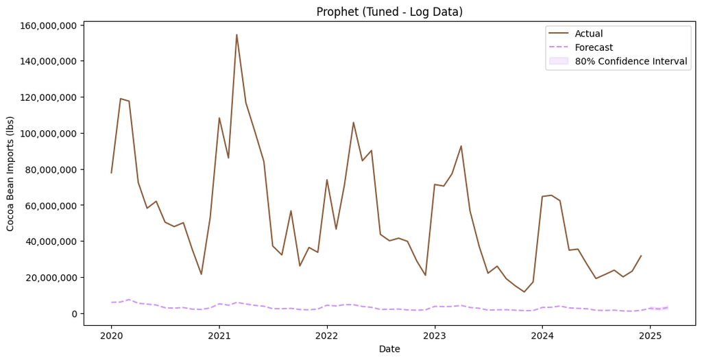

```python
m_log = Prophet(
    yearly_seasonality=True,
    weekly_seasonality=False,
    daily_seasonality=False,
    **best_params_log
)

m_log.fit(df_log)

future_log = m_log.make_future_dataframe(periods=3, freq='MS')
future_log['floor'] = np.log1p(0)
future_log['cap'] = np.log1p(cap_value)

forecast_log = m_log.predict(future_log)

forecast_log['yhat_orig'] = np.expm1(forecast_log['yhat'])
forecast_log['yhat_lower_orig'] = np.expm1(forecast_log['yhat_lower'])
forecast_log['yhat_upper_orig'] = np.expm1(forecast_log['yhat_upper'])

plt.figure(figsize=(12, 6))

plt.plot(df['ds'], df['y'], label="Actual", color=custom_palette[2])

plt.plot(forecast_log['ds'], forecast_log['yhat_orig'], label="Forecast", color=custom_palette[0], linestyle='--')

future_forecast_log = forecast_log[forecast_log['ds'] > df_log['ds'].max()]
plt.fill_between(
    future_forecast_log['ds'],
    future_forecast_log['yhat_lower_orig'],
    future_forecast_log['yhat_upper_orig'],
    color=custom_palette[0],
    alpha=0.2,
    label='80% Confidence Interval'
)

ax = plt.gca()
ax.yaxis.set_major_formatter(mtick.StrMethodFormatter('{x:,.0f}'))

plt.legend()
plt.ylabel("Cocoa Bean Imports (lbs)")
plt.xlabel("Date")
plt.title("Prophet (Tuned - Log Data)")
plt.show()
```

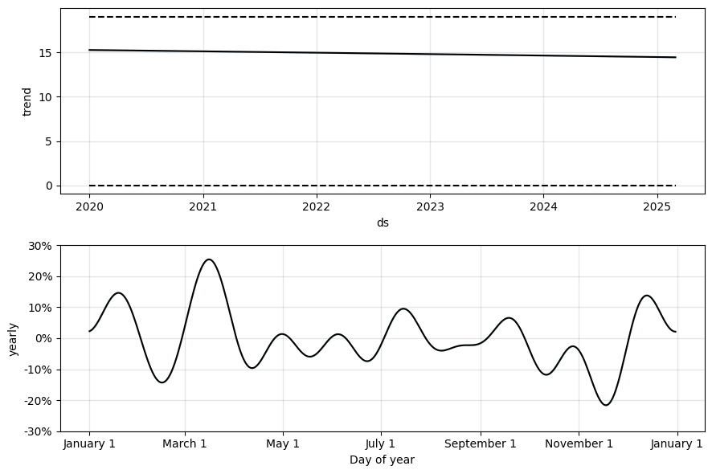

```python
fig = m_log.plot_components(forecast_log)

for ax in fig.axes:
    for line in ax.get_lines():
        line.set_color('black')
plt.show()
```

```python
prophet_tuned_log_cv= cv_orig

prophet_tuned_log_cv['AE'] = abs(prophet_tuned_log_cv['yhat_orig'] - prophet_tuned_log_cv['y_orig'])
prophet_tuned_log_cv['APE'] = (abs(prophet_tuned_log_cv['yhat_orig'] - prophet_tuned_log_cv['y_orig']) / abs(prophet_tuned_log_cv['y_orig']))

prophet_tuned_log_cv['ds'] = pd.to_datetime(prophet_tuned_log_cv['ds'])
prophet_tuned_log_cv['cutoff'] = pd.to_datetime(prophet_tuned_log_cv['cutoff'])
prophet_tuned_log_cv['horizon'] = prophet_tuned_log_cv['ds'].dt.to_period('M').astype(int) - prophet_tuned_log_cv['cutoff'].dt.to_period('M').astype(int)
prophet_tuned_log_cv.style.format({'ds':'{:%m-%d-%Y}','cutoff':'{:%m-%d-%Y}','y':'{:,.2f}','y_orig':'{:,.0f}','yhat':'{:,.2f}','yhat_lower':'{:,.2f}',
                                   'yhat_upper':'{:,.2f}','yhat_orig':'{:,.0f}','yhat_lower_orig':'{:,.0f}',
                                   'yhat_upper_orig':'{:,.0f}','AE': '{:,.0f}', 'APE': '{:.0%}'})
```

|  | ds | yhat | yhat_lower | yhat_upper | y | cutoff | y_orig | yhat_orig | AE | APE | horizon |
| --- | --- | --- | --- | --- | --- | --- | --- | --- | --- | --- | --- |
| 0 | 10-01-2023 | 17.47 | 17.20 | 17.71 | 16.53 | 09-01-2023 | 15,172,388 | 38,590,845 | 23,418,457 | 154% | 1 |
| 1 | 11-01-2023 | 17.49 | 17.24 | 17.73 | 16.28 | 09-01-2023 | 11,741,002 | 39,427,067 | 27,686,065 | 236% | 2 |
| 2 | 12-01-2023 | 16.42 | 16.16 | 16.68 | 16.67 | 09-01-2023 | 17,305,596 | 13,487,256 | 3,818,340 | 22% | 3 |
| 3 | 11-01-2023 | 17.64 | 17.35 | 17.92 | 16.28 | 10-01-2023 | 11,741,002 | 45,870,173 | 34,129,171 | 291% | 1 |
| 4 | 12-01-2023 | 16.51 | 16.23 | 16.78 | 16.67 | 10-01-2023 | 17,305,596 | 14,823,024 | 2,482,572 | 14% | 2 |
| 5 | 01-01-2024 | 17.57 | 17.26 | 17.82 | 17.99 | 10-01-2023 | 64,702,033 | 42,506,011 | 22,196,022 | 34% | 3 |
| 6 | 12-01-2023 | 16.81 | 16.51 | 17.15 | 16.67 | 11-01-2023 | 17,305,596 | 19,974,901 | 2,669,305 | 15% | 1 |
| 7 | 01-01-2024 | 17.57 | 17.24 | 17.89 | 17.99 | 11-01-2023 | 64,702,033 | 42,553,675 | 22,148,358 | 34% | 2 |
| 8 | 02-01-2024 | 17.75 | 17.43 | 18.06 | 18.00 | 11-01-2023 | 65,375,575 | 51,167,470 | 14,208,105 | 22% | 3 |
| 9 | 01-01-2024 | 17.58 | 17.25 | 17.90 | 17.99 | 12-01-2023 | 64,702,033 | 43,184,329 | 21,517,704 | 33% | 1 |
| 10 | 02-01-2024 | 17.76 | 17.45 | 18.07 | 18.00 | 12-01-2023 | 65,375,575 | 51,784,211 | 13,591,364 | 21% | 2 |
| 11 | 03-01-2024 | 18.06 | 17.74 | 18.35 | 17.95 | 12-01-2023 | 62,364,919 | 69,550,697 | 7,185,778 | 12% | 3 |
| 12 | 02-01-2024 | 17.82 | 17.49 | 18.14 | 18.00 | 01-01-2024 | 65,375,575 | 54,631,649 | 10,743,926 | 16% | 1 |
| 13 | 03-01-2024 | 18.14 | 17.82 | 18.43 | 17.95 | 01-01-2024 | 62,364,919 | 75,588,776 | 13,223,857 | 21% | 2 |
| 14 | 04-01-2024 | 17.74 | 17.43 | 18.05 | 17.37 | 01-01-2024 | 34,933,233 | 50,672,081 | 15,738,848 | 45% | 3 |
| 15 | 03-01-2024 | 18.16 | 17.84 | 18.49 | 17.95 | 02-01-2024 | 62,364,919 | 77,281,349 | 14,916,430 | 24% | 1 |
| 16 | 04-01-2024 | 17.76 | 17.44 | 18.07 | 17.37 | 02-01-2024 | 34,933,233 | 51,536,485 | 16,603,252 | 48% | 2 |
| 17 | 05-01-2024 | 17.61 | 17.30 | 17.91 | 17.39 | 02-01-2024 | 35,504,037 | 44,366,014 | 8,861,977 | 25% | 3 |
| 18 | 04-01-2024 | 17.76 | 17.44 | 18.08 | 17.37 | 03-01-2024 | 34,933,233 | 51,504,978 | 16,571,745 | 47% | 1 |
| 19 | 05-01-2024 | 17.60 | 17.27 | 17.90 | 17.39 | 03-01-2024 | 35,504,037 | 44,167,722 | 8,663,685 | 24% | 2 |
| 20 | 06-01-2024 | 17.60 | 17.28 | 17.95 | 17.11 | 03-01-2024 | 26,935,635 | 44,130,722 | 17,195,087 | 64% | 3 |
| 21 | 05-01-2024 | 17.59 | 17.26 | 17.89 | 17.39 | 04-01-2024 | 35,504,037 | 43,407,845 | 7,903,808 | 22% | 1 |
| 22 | 06-01-2024 | 17.58 | 17.26 | 17.90 | 17.11 | 04-01-2024 | 26,935,635 | 43,166,578 | 16,230,943 | 60% | 2 |
| 23 | 07-01-2024 | 17.07 | 16.74 | 17.37 | 16.77 | 04-01-2024 | 19,175,494 | 25,913,220 | 6,737,726 | 35% | 3 |
| 24 | 06-01-2024 | 17.58 | 17.27 | 17.89 | 17.11 | 05-01-2024 | 26,935,635 | 43,273,502 | 16,337,867 | 61% | 1 |
| 25 | 07-01-2024 | 17.07 | 16.77 | 17.39 | 16.77 | 05-01-2024 | 19,175,494 | 25,927,086 | 6,751,592 | 35% | 2 |
| 26 | 08-01-2024 | 16.84 | 16.51 | 17.13 | 16.88 | 05-01-2024 | 21,449,146 | 20,524,610 | 924,536 | 4% | 3 |
| 27 | 07-01-2024 | 17.07 | 16.75 | 17.39 | 16.77 | 06-01-2024 | 19,175,494 | 25,962,683 | 6,787,189 | 35% | 1 |
| 28 | 08-01-2024 | 16.83 | 16.51 | 17.14 | 16.88 | 06-01-2024 | 21,449,146 | 20,406,110 | 1,043,036 | 5% | 2 |
| 29 | 09-01-2024 | 17.04 | 16.72 | 17.37 | 16.99 | 06-01-2024 | 23,828,291 | 25,145,438 | 1,317,147 | 6% | 3 |
| 30 | 08-01-2024 | 16.83 | 16.51 | 17.13 | 16.88 | 07-01-2024 | 21,449,146 | 20,314,748 | 1,134,398 | 5% | 1 |
| 31 | 09-01-2024 | 17.03 | 16.69 | 17.35 | 16.99 | 07-01-2024 | 23,828,291 | 24,945,848 | 1,117,557 | 5% | 2 |
| 32 | 10-01-2024 | 16.48 | 16.18 | 16.81 | 16.82 | 07-01-2024 | 20,121,692 | 14,391,758 | 5,729,934 | 28% | 3 |
| 33 | 09-01-2024 | 17.04 | 16.72 | 17.36 | 16.99 | 08-01-2024 | 23,828,291 | 25,143,218 | 1,314,927 | 6% | 1 |
| 34 | 10-01-2024 | 16.49 | 16.17 | 16.81 | 16.82 | 08-01-2024 | 20,121,692 | 14,497,193 | 5,624,499 | 28% | 2 |
| 35 | 11-01-2024 | 16.29 | 15.96 | 16.61 | 16.96 | 08-01-2024 | 23,311,088 | 11,830,985 | 11,480,103 | 49% | 3 |

```python
MAE_by_horizon_log = prophet_tuned_log_cv.groupby(['horizon'])['AE'].mean()
MAE_by_horizon_log = pd.DataFrame(MAE_by_horizon_log).rename(columns={'AE': 'MAE'})

MAPE_by_horizon_log = prophet_tuned_log_cv.groupby(['horizon'])['APE'].mean()
MAPE_by_horizon_log = pd.DataFrame(MAPE_by_horizon_log).rename(columns={'APE': 'MAPE'})

prophet_tuned_log_horizon_table = MAE_by_horizon_log.merge(MAPE_by_horizon_log,on='horizon')
prophet_tuned_log_horizon_table.style.format({'MAE': '{:,.0f}', 'MAPE': '{:.0%}'})
```

| horizon | MAE | MAPE |
| --- | --- | --- |
| 1 | 13,120,411 | 59% |
| 2 | 11,263,898 | 44% |
| 3 | 9,616,134 | 29% |

The log transformation did not meaningfully improve the performance:

```python
prophet_tuned_log_overall_MAE  = prophet_tuned_log_cv['AE'].mean()
prophet_tuned_log_overall_MAPE = prophet_tuned_log_cv['APE'].mean()

print(f"MAE: {prophet_tuned_log_overall_MAE:,.0f}")
print(f"MAPE (%): {prophet_tuned_log_overall_MAPE:.0%}")
```

```
MAE: 11,333,481
MAPE (%): 44%
```

[figure not shown]

Overall Model Metrics:

Note, only includes the tuned models above:

```python
final_table = pd.DataFrame({
    'Model': [
        'ExponentialSmoothing','ExponentialSmoothing',
        'Sarima','Sarima','Sarima','Sarima','Sarima','Sarima',
        'Prophet','Prophet'
    ],
    'Log Data': ['N','Y','N','N','N','Y','Y','Y','N','Y'],
    'Tuning': [
        'Manual','Manual',
        'Short Grid Search','Grid Search','Manual',
        'Short Grid Search','Grid Search','Manual',
        'Grid Search','Grid Search'
    ],

    'MAE': [
        exp_ts_tuned_overall_MAE,
        exp_ts_tuned_log_overall_MAE,
        sarima_auto_overall_MAE,
        sarima_flex_full_overall_MAE,
        sarima_manual_overall_MAE,
        sarima_log_auto_overall_MAE,
        sarima_log_full_flex_overall_MAE,
        sarima_log_manual_overall_MAE,
        prophet_tuned_overall_MAE,
        prophet_tuned_log_overall_MAE
    ],

    'MAPE': [
        exp_ts_tuned_overall_MAPE,
        exp_ts_tuned_log_overall_MAPE,
        sarima_auto_overall_MAPE,
        sarima_flex_full_overall_MAPE,
        sarima_manual_overall_MAPE,
        sarima_log_auto_overall_MAPE,
        sarima_log_full_flex_overall_MAPE,
        sarima_log_manual_overall_MAPE,
        prophet_tuned_overall_MAPE,
        prophet_tuned_log_overall_MAPE
    ],

    'MAE_H1': [
        exp_ts_tuned_cv['MAE'][1],
        exp_ts_tuned_log_cv['MAE'][1],
        sarima_auto_cv['MAE'][1],
        sarima_flex_full_cv['MAE'][1],
        sarima_manual_cv['MAE'][1],
        sarima_log_auto_cv['MAE'][1],
        sarima_log_full_flex_cv['MAE'][1],
        sarima_log_manual_cv['MAE'][1],
        prophet_tuned_horizon_table['MAE'][1],
        prophet_tuned_log_horizon_table['MAE'][1]
    ],

    'MAE_H2': [
        exp_ts_tuned_cv['MAE'][2],
        exp_ts_tuned_log_cv['MAE'][2],
        sarima_auto_cv['MAE'][2],
        sarima_flex_full_cv['MAE'][2],
        sarima_manual_cv['MAE'][2],
        sarima_log_auto_cv['MAE'][2],
        sarima_log_full_flex_cv['MAE'][2],
        sarima_log_manual_cv['MAE'][2],
        prophet_tuned_horizon_table['MAE'][2],
        prophet_tuned_log_horizon_table['MAE'][2]
    ],

    'MAE_H3': [
        exp_ts_tuned_cv['MAE'][3],
        exp_ts_tuned_log_cv['MAE'][3],
        sarima_auto_cv['MAE'][3],
        sarima_flex_full_cv['MAE'][3],
        sarima_manual_cv['MAE'][3],
        sarima_log_auto_cv['MAE'][3],
        sarima_log_full_flex_cv['MAE'][3],
        sarima_log_manual_cv['MAE'][3],
        prophet_tuned_horizon_table['MAE'][3],
        prophet_tuned_log_horizon_table['MAE'][3]
    ],

    'MAPE_H1': [
        exp_ts_tuned_cv['MAPE'][1],
        exp_ts_tuned_log_cv['MAPE'][1],
        sarima_auto_cv['MAPE'][1],
        sarima_flex_full_cv['MAPE'][1],
        sarima_manual_cv['MAPE'][1],
        sarima_log_auto_cv['MAPE'][1],
        sarima_log_full_flex_cv['MAPE'][1],
        sarima_log_manual_cv['MAPE'][1],
        prophet_tuned_horizon_table['MAPE'][1],
        prophet_tuned_log_horizon_table['MAPE'][1]
    ],

    'MAPE_H2': [
        exp_ts_tuned_cv['MAPE'][2],
        exp_ts_tuned_log_cv['MAPE'][2],
        sarima_auto_cv['MAPE'][2],
        sarima_flex_full_cv['MAPE'][2],
        sarima_manual_cv['MAPE'][2],
        sarima_log_auto_cv['MAPE'][2],
        sarima_log_full_flex_cv['MAPE'][2],
        sarima_log_manual_cv['MAPE'][2],
        prophet_tuned_horizon_table['MAPE'][2],
        prophet_tuned_log_horizon_table['MAPE'][2]
    ],

    'MAPE_H3': [
        exp_ts_tuned_cv['MAPE'][3],
        exp_ts_tuned_log_cv['MAPE'][3],
        sarima_auto_cv['MAPE'][3],
        sarima_flex_full_cv['MAPE'][3],
        sarima_manual_cv['MAPE'][3],
        sarima_log_auto_cv['MAPE'][3],
        sarima_log_full_flex_cv['MAPE'][3],
        sarima_log_manual_cv['MAPE'][3],
        prophet_tuned_horizon_table['MAPE'][3],
        prophet_tuned_log_horizon_table['MAPE'][3]
    ]
})
```

```python
final_table.style.format({
    'MAE': '{:,.0f}',
    'MAPE': '{:.0%}',
    'MAE_H1': '{:,.0f}',
    'MAE_H2': '{:,.0f}',
    'MAE_H3': '{:,.0f}',
    'MAPE': '{:.0%}',
    'MAPE_H1': '{:.0%}',
    'MAPE_H2': '{:.0%}',
    'MAPE_H3': '{:.0%}'
})
```

|  | Model | Log Data | Tuning | MAE | MAPE | MAE_H1 | MAE_H2 | MAE_H3 | MAPE_H1 | MAPE_H2 | MAPE_H3 |
| --- | --- | --- | --- | --- | --- | --- | --- | --- | --- | --- | --- |
| 0 | ExponentialSmoothing | N | Manual | 9,559,131 | 27% | 8,232,452 | 9,662,806 | 10,782,135 | 24% | 29% | 30% |
| 1 | ExponentialSmoothing | Y | Manual | 10,529,595 | 29% | 8,454,615 | 10,832,569 | 12,301,600 | 24% | 30% | 33% |
| 2 | Sarima | N | Short Grid Search | 22,830,464 | 92% | 17,133,558 | 23,203,094 | 28,154,741 | 69% | 97% | 110% |
| 3 | Sarima | N | Grid Search | 9,843,491 | 33% | 8,015,458 | 10,640,699 | 10,874,315 | 29% | 37% | 33% |
| 4 | Sarima | N | Manual | 22,289,579 | 92% | 16,481,605 | 23,139,574 | 27,247,558 | 72% | 99% | 105% |
| 5 | Sarima | Y | Short Grid Search | 9,876,261 | 27% | 8,184,446 | 9,970,251 | 11,474,088 | 22% | 27% | 31% |
| 6 | Sarima | Y | Grid Search | 9,324,128 | 26% | 7,426,062 | 9,404,383 | 11,141,939 | 21% | 27% | 30% |
| 7 | Sarima | Y | Manual | 10,270,420 | 29% | 8,355,908 | 10,535,363 | 11,919,988 | 24% | 30% | 33% |
| 8 | Prophet | N | Grid Search | 11,510,718 | 46% | 12,449,653 | 11,544,815 | 10,537,687 | 54% | 47% | 37% |
| 9 | Prophet | Y | Grid Search | 11,333,481 | 44% | 13,120,411 | 11,263,898 | 9,616,134 | 59% | 44% | 29% |

# Results

[figure not shown]

```python
final_model=final_table.iloc[[0]]
final_model.style.format({
    'MAE': '{:,.0f}',
    'MAPE': '{:.0%}',
    'MAE_H1': '{:,.0f}',
    'MAE_H2': '{:,.0f}',
    'MAE_H3': '{:,.0f}',
    'MAPE': '{:.0%}',
    'MAPE_H1': '{:.0%}',
    'MAPE_H2': '{:.0%}',
    'MAPE_H3': '{:.0%}'
})
```

|  | Model | Log Data | Tuning | MAE | MAPE | MAE_H1 | MAE_H2 | MAE_H3 | MAPE_H1 | MAPE_H2 | MAPE_H3 |
| --- | --- | --- | --- | --- | --- | --- | --- | --- | --- | --- | --- |
| 0 | ExponentialSmoothing | N | Manual | 9,559,131 | 27% | 8,232,452 | 9,662,806 | 10,782,135 | 24% | 29% | 30% |

```python
display(Image(url="https://raw.githubusercontent.com/lindsayalexandra14/ds_portfolio/main/1_projects/machine_learning/time_series_and_survival/cocoa_imports/cocoa_imports_final_model_plot.png",
    width=800))
```

[figure not shown]

| Date | Forecast | Lower_CI | Upper_CI |
| --- | --- | --- | --- |
| 2025-01-01 | 59,915,879 | 31,650,287 | 67,112,957 |
| 2025-02-01 | 59,477,191 | 30,411,927 | 65,506,481 |
| 2025-03-01 | 75,993,848 | 38,341,516 | 84,996,332 |

Future Improvements:

Additions on this project could include adding additional regressors, like the global market price of Cocoa Beans or the supply, and/or forecasting by country or continent. Removing outliers by country first may also improve performance, however recent anomalies due to supply or price may continue moving forward and removing them may be detrimental.